# Технология 100VG-AnyLAN

РОССИЙСКИЙ УНИВЕРСИТЕТ ДРУЖБЫ НАРОДОВ

Кулябов Дмитрий Сергеевич

д.ф.-м.н., профессор

профессор кафедры прикладной информатики и теории вероятностей

Устинова В. В.

Российский университет дружбы народов, Москва, Россия

22 октября 2026

# Информация

## Докладчик

- Устинова Виктория Вадимовна
- студент НПИбд-01-24
- Российский университет дружбы народов
- 1132243111@pfur.ru
- https://github.com/vikauustin

# Оглавление

## Cодержание

1. Вводная часть

2. Цель, гипотеза, задачи и исследования

3. Материалы и методы и инструменты исследования, теоретическая база

4. Содержание исследования

5. Анализ и пректическая значимость достигнутых результатов

6. Общее заключение и выводы

## Вводная часть

*Актуальность*:

- Идеи 100VG-AnyLAN живут в коммутируемых сетях Ethernet и QoS.
- Пример того,что решает не только техника,но и совместимость и цена
- Предсказуемая доставка трафика снова актуальна(системы реального времени) *Объект исследования:* высокоскоростные локальные сети 100Мбит/с *Предмет исследования:* технология 100VG- AnyLAN

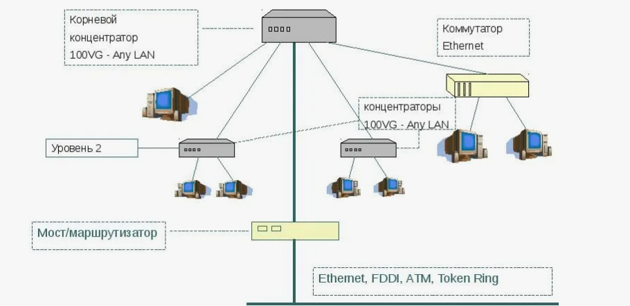

История технологии

## Научиная новизна, практическая значимость работы

*Научная новизна:*

• систематизация сведений о 100VG-AnyLAN

• анализ причин её поражения в конкуренции с Fast Ethernet

• связи идей технологий с современными сетями.

*Практическая значимость:*

• Материалы работы могут использоваться при изучении курса сетевых технологий: методов доступа к среде

• сравнение технологий локальных сетей и истории их развития

## Цель, гипотеза, задачи и исследования

*Цель:* изучить технологию 100VG-AnyLAN, её принципы работы и место среди технологий локальных сетей

*Гипотеза:* технического превосходства недостаточно для успеха сетевой технологии; решающими оказываются совместимость, стоимость и поддержка производителей

*Задачи:*

- Рассмотреть историю появления технологии и её стандартизацию.
- Изучить архитектуру сети и роль концентраторов.
- Разобрать метод доступа Demand Priority.
- Описать физический уровень технологии.
- Сравнить 100VG-AnyLAN с Fast Ethernet.

## Материалы и методы и инструменты исследования, теоретическая база

Материалы: учебники Олифера и Таненбаума, стандарт IEEE 802.12

Методы: анализ, сравнительный анализ, систематизация

Теоретическая база:

1. уровни OSI: физический и канальный (MAC)
2. случайный доступ CSMA/CD — коллизии
3. детерминированный доступ — маркер или опрос, коллизий нет

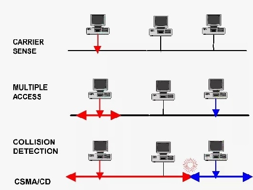

## Содержание исследования

**Предлагаемое решение задач с обоснованием**

Подход: последовательный, по уровням модели OSI

Порядок: история → архитектура → метод доступа → физический уровень → сравнение

Обоснование: сравнение по единым критериям позволяет проверить гипотезу

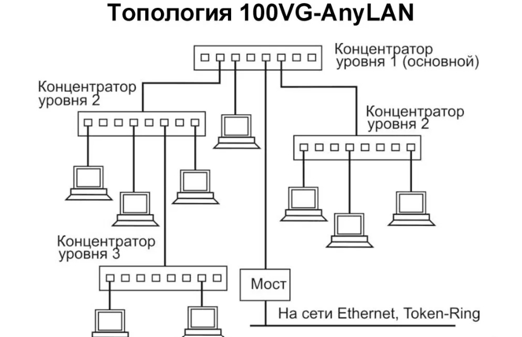

Иерархическая звезда

## Основные этапы(1-3)

Этап 1. История: HP и AT&T, 1993–1995, стандарт IEEE 802.12

Этап 2. Архитектура:

звезда / иерархическая звезда до 3 уровней

концентратор управляет доступом, кадр — только получателю

Этап 3. Demand Priority:

узел запрашивает, концентратор разрешает по очереди

два приоритета, коллизий нет

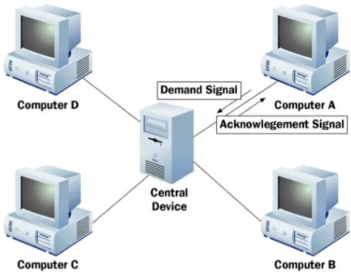

Цикл опроса

## Основные этапы(4-5)

Этап 4. Физический уровень:

витая пара кат. 3, 4 пары

квартетное кодирование 5B/6B + NRZ

4 × 25 = 100 Мбит/с, полудуплекс

Этап 5. Сравнение с Fast Ethernet:

нет коллизий, есть приоритеты, кадры Ethernet и Token Ring

но нет совместимости с 10BASE-T

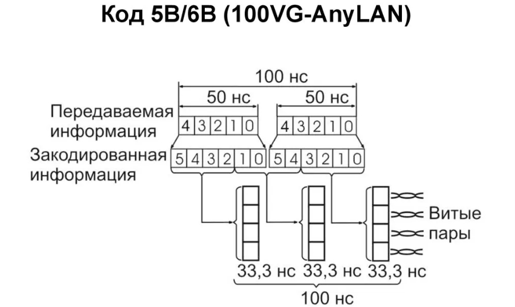

Квартетное кодирование

## Анализ и практическая значимость достигнутых результатов

**Почему победил Fast Ethernet:** совместимость с Ethernet и автосогласование 10/100, дешёвое оборудование многих производителей, массовый кабель категории 5, коммутаторы и полный дуплекс убрали коллизии, дальнейшее развитие — Gigabit Ethernet

**Достоинства 100VG-AnyLAN:** нет коллизий, приоритеты, два формата кадров, старый кабель

**Недостатки:** несовместимость, дорогие концентраторы, мало производителей, полудуплекс

## Общее заключение и выводы

**Выводы:**

1. 100VG-AnyLAN — альтернатива Fast Ethernet с детерминированным доступом
2. Demand Priority исключает коллизии и даёт малую задержку для голоса и видео
3. Квартетное кодирование позволило 100 Мбит/с по кабелю категории 3
4. Технология проиграла из-за несовместимости, цены и появления коммутаторов
5. Её идеи сохранились в современных коммутируемых сетях Ethernet

*Итог:* гипотеза подтвердилась — техническое превосходство не гарантирует успеха